# Data Processing for Low Carb High Fat Diet

Repeated measures on subjects

Mark Connolly

2016-10-12

# Introduction

Analysis of collected observations. Weaving executed code with explanatory text to produce literate programming (Knuth 1984) is provided by the R packages `knitr` (Xie 2016) and the document template `tufte` (Xie and Allaire 2016).

Knuth, Donald Ervin. 1984. “Literate Programming.” *The Computer Journal* 27 (2): 97–111.

Xie, Yihui. 2016. *Knitr: A General-Purpose Package for Dynamic Report Generation in R*. https://CRAN.R-project.org/package=knitr.

Xie, Yihui, and JJ Allaire. 2016. *Tufte: Tufte’s Styles for R Markdown Documents*. https://CRAN.R-project.org/package=tufte.

This document is translated from rmarkdown (Allaire et al. 2016) source. The source can be found at [LCHF Analysis.Rmd](https://github.com/markconnolly/lchf/blob/master/LCHF%20Analysis.Rmd).

Allaire, JJ, Joe Cheng, Yihui Xie, Jonathan McPherson, Winston Chang, Jeff Allen, Hadley Wickham, Aron Atkins, and Rob Hyndman. 2016. *Rmarkdown: Dynamic Documents for R*. http://rmarkdown.rstudio.com.

The `%>%` operator will be seen in some of the code. The package `magrittr` (Bache and Wickham 2014) provides this operator, called a pipe, which forwards the result of a preceeding function to a suceeding function in a sinle code stream. By default, the forwarded object is “piped” into the succeeding function’s first parameter slot. The argument can be moved to other parameter slots in the succeeding call Using the `.` placeholder. The pipe is used where it improves readability. A series of functions interspersed with `%>%` should be viewed as pipeline or processing elements, with the output of one function the input to the next.

Bache, Stefan Milton, and Hadley Wickham. 2014. *Magrittr: A Forward-Pipe Operator for R*. https://CRAN.R-project.org/package=magrittr.

R uses formulae to define response models. A formula is the form

`response variable ~ explanatory variables`

The structure of formulae is well-explained by (“R Tutorials–Model Formulae” 2016).

“R Tutorials–Model Formulae.” 2016. https://ww2.coastal.edu/kingw/statistics/R-tutorials/formulae.html. Accessed September 10.

# Plots of observation variables

## Data preparation

```r
excelfilter <- matrix(c("Excel", "*.xls*"), ncol=2)

rer <- choose.files(filters = excelfilter,
                    caption = "Select rer file",
                    multi=FALSE) %>%
       read_excel(sheet=1)

# make the names more convenient to use
names(rer) <- gsub(" ", "", names(rer), fixed=TRUE)
names(rer) <- gsub("(", "_", names(rer), fixed=TRUE)
names(rer) <- gsub(")", "", names(rer), fixed=TRUE)
names(rer) <- gsub("%", "pct", names(rer), fixed=TRUE)

# convert factors to factors
rer$Subject <- as.factor(rer$Subject)
rer$TestNumber <- as.factor(rer$TestNumber)

rer2 <- rer[c("Subject","TestNumber",
              "RERHR",
              "MaxRelVO2","MaxAbsVO2",
              "BFpctBIA","SFBFpct",
              "MoodB4_cm","MoodAfter_cm",
              "FatBIA","FatSF")]

rer2_long <-
  rer[c("Subject","TestNumber",
        "RERHR",
        "MaxRelVO2","MaxAbsVO2",
        "BFpctBIA","SFBFpct",
        "MoodB4_cm","MoodAfter_cm",
        "FatBIA","FatSF")]            %>%
  gather(measurement,obs,RERHR:FatSF)
rer2_long$measurement <-
  ordered(rer2_long$measurement,
          levels = c("RERHR",
                     "MaxRelVO2","MaxAbsVO2",
                     "BFpctBIA","SFBFpct",
                     "MoodB4_cm","MoodAfter_cm",
                     "FatBIA","FatSF"))
```

## RER Heartrate

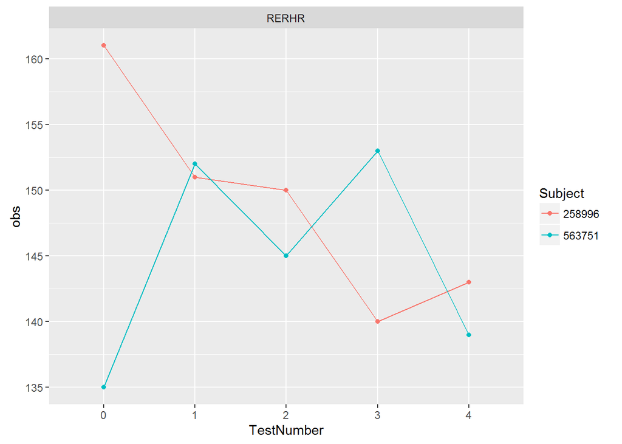

```r
scales <- "fixed";columns <- c("RERHR")
rer2_long %>%
  subset(measurement %in% columns) %>%
  ggplot(data=., aes(x=TestNumber,
                     y=obs,
                     color=Subject,
                     group = Subject)) +
  geom_point() +
  geom_line() +
  facet_wrap(~measurement, scales = scales)
```

## VO2 Max

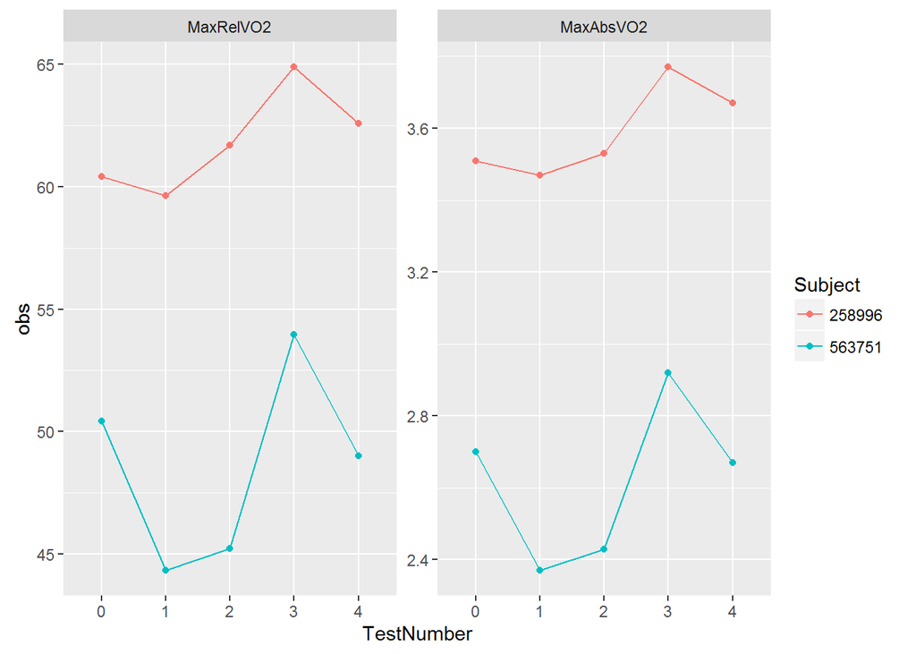

```r
scales <- "free";columns <- c("MaxRelVO2","MaxAbsVO2")
rer2_long %>%
  subset(measurement %in% columns) %>%
  ggplot(data=., aes(x=TestNumber,
                     y=obs,
                     color=Subject,
                     group = Subject)) +
  geom_point() +
  geom_line() +
  facet_wrap(~measurement, scales = scales)
```

## Body fat

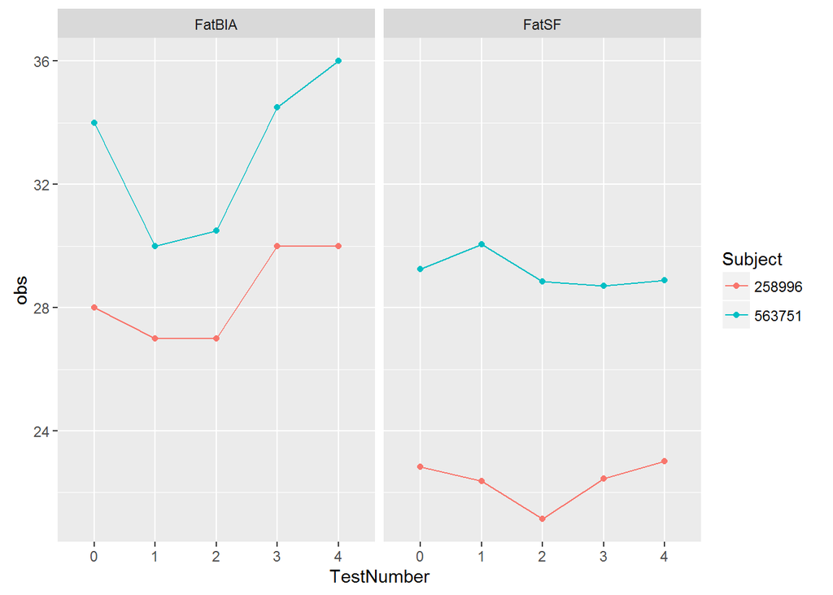

```r
scales <- "fixed";columns <- c("FatBIA","FatSF")
rer2_long %>%
  subset(measurement %in% columns) %>%
  ggplot(data=., aes(x=TestNumber,
                     y=obs,
                     color=Subject,
                     group = Subject)) +
  geom_point() +
  geom_line() +
  facet_wrap(~measurement, scales = scales)
```

## Percent body fat

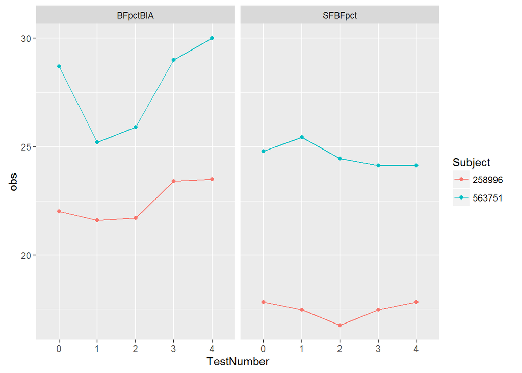

```r
scales <- "fixed";columns <- c("BFpctBIA","SFBFpct")
rer2_long %>%
  subset(measurement %in% columns) %>%
  ggplot(data=., aes(x=TestNumber,
                     y=obs,
                     color=Subject,
                     group = Subject)) +
  geom_point() +
  geom_line() +
  facet_wrap(~measurement, scales = scales)
```

## Mood ring readings

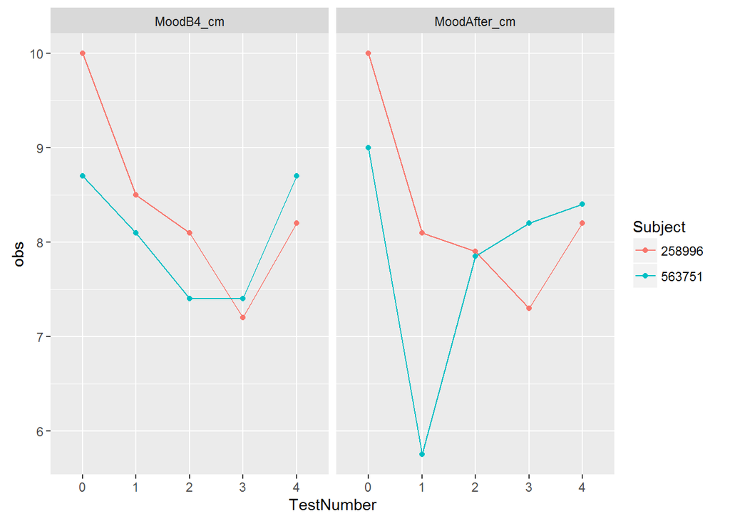

```r
scales <- "fixed";columns <- c("MoodB4_cm","MoodAfter_cm")
rer2_long %>%
  subset(measurement %in% columns) %>%
  ggplot(data=., aes(x=TestNumber,
                     y=obs,
                     color=Subject,
                     group = Subject)) +
  geom_point() +
  geom_line() +
  facet_wrap(~measurement, scales = scales)
```

# Heartrate at RER 0.5

For later

Heartrate at RER 0.5 is the dependent variable. The hypothesis is that the low carbohydrate/high fat diet will increase the heartrate at RER, with the body becoming using more fat than protien as the testing procedes.

Working model for analysis: (Gribble 2009)

Gribble, Paul. 2009. “Repeated Measures ANOVA Using R.” *Motor Control Lab Blog*. https://gribblelab.wordpress.com/2009/03/09/repeated-measures-anova-using-r/.

`summary(aov(RERHR ~ Error(Subject), data=rer))`